# **Unsupervised Learning Project: AllLife Bank Customer Segmentation**

### **Question 3: Check the distribution and outliers for each variable in the data.**

- **Check the distribution of all variables (use .hist() attribute) (2 Marks)**
- **Check outliers for all variables (use sns.boxplot()) (2 Mark)**
- **Write your observations (1 Marks)**

```
Avg_Credit_Limit
Skew : 2.19
```

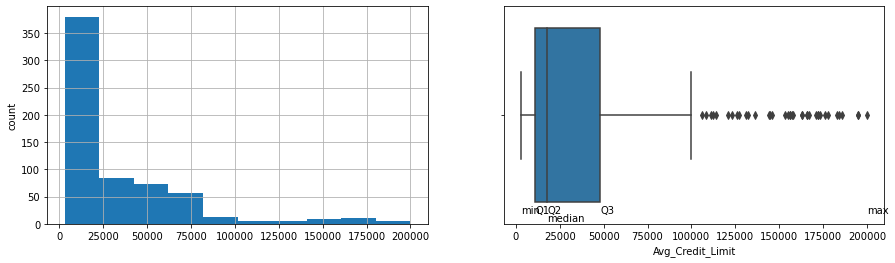

```
Total_Credit_Cards
Skew : 0.17
```

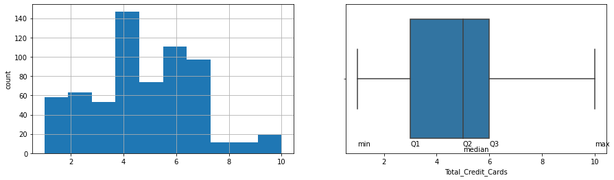

```
Total_visits_bank
Skew : 0.15
```

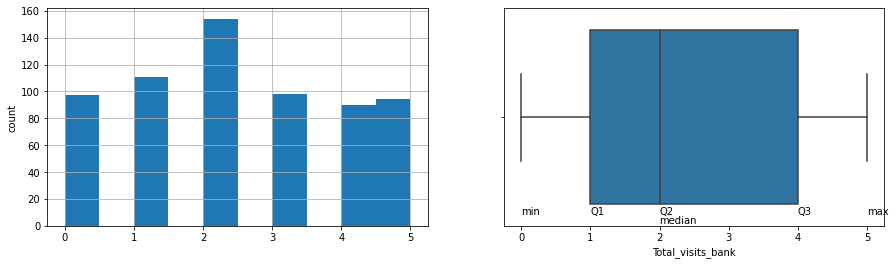

```
Total_visits_online
Skew : 2.21
```

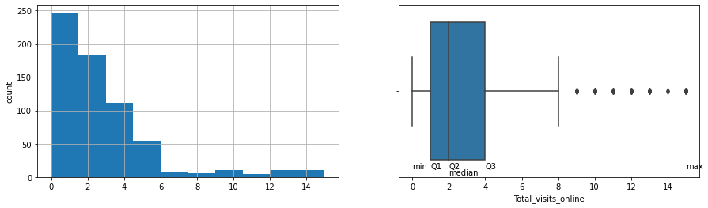

```
Total_calls_made
Skew : 0.65
```

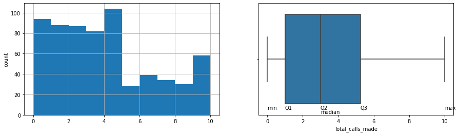

```python
# complete the BELOW code by filling the blanks, before running the cell to avoid any errors

for col in data.columns:
    print(col)

    print('Skew :', round(data[col].skew(), 2))

    plt.figure(figsize = (15, 4))

    plt.subplot(1, 2, 1)

    data[col].hist() #____

    plt.ylabel('count')

    # plt.subplot(1, 2, 1)
    # sns.distplot(data[col])

    plt.subplot(1, 2, 2)

    sns.boxplot(x = data[col]) # ___________)

    plt.text(y=0.45, x=data[col].min(), s='min')
    plt.text(y=0.45, x=data[col].quantile(0.25), s='Q1')
    plt.text(y=0.45, x=data[col].median(), s='Q2')
    plt.text(y=0.49, x=data[col].median(), s='median')
    plt.text(y=0.45, x=data[col].quantile(0.75), s='Q3')
    plt.text(y=0.45, x=data[col].max(), s='max')

    plt.show()
```

### **Checking correlation**

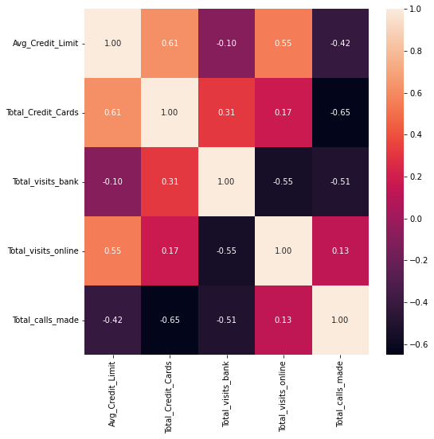

```python
plt.figure(figsize = (8, 8))

sns.heatmap(data.corr(), annot = True, fmt = '0.2f')

plt.show()
```

### **Scaling the data**

```python
scaler = StandardScaler()

# Standardize the data to have a mean of ~0 and a variance of 1
data_scaled = StandardScaler().fit_transform(data)

data_scaled1 = pd.DataFrame(scaler.fit_transform(data), columns=data.columns) #to see in tabular form later.
```

```python
data_scaled # just wanted to see
```

```
array([[ 1.75019153, -1.23943654, -0.85868369, -0.54957262, -1.25398247],
       [ 0.41328003, -0.77938056, -1.47380305,  2.49566917,  1.8734196 ],
       [ 0.41328003,  1.06084338, -0.85868369,  0.12714778,  0.135974  ],
       ...,
       [ 2.95341188,  1.52089937, -0.85868369,  2.15730897, -0.90649335],
       [ 3.67534409,  2.44101134, -0.85868369,  4.18747017, -1.25398247],
       [ 3.54165294,  1.98095535, -1.47380305,  3.17238957, -0.55900423]])
```

```python
data_scaled1.head()
```

|  | Avg_Credit_Limit | Total_Credit_Cards | Total_visits_bank | Total_visits_online | Total_calls_made |
| --- | --- | --- | --- | --- | --- |
| 0 | 1.750192 | -1.239437 | -0.858684 | -0.549573 | -1.253982 |
| 1 | 0.413280 | -0.779381 | -1.473803 | 2.495669 | 1.873420 |
| 2 | 0.413280 | 1.060843 | -0.858684 | 0.127148 | 0.135974 |
| 3 | -0.121485 | 0.140731 | -0.858684 | -0.549573 | 0.135974 |
| 4 | 1.750192 | 0.600787 | -1.473803 | 3.172390 | -0.211515 |

### **Applying PCA on scaled data**

```python
from sklearn.decomposition import PCA

n = data.shape[1]
print('number of principal components', n)

# Create a PCA instance: pca
pca = PCA(n_components=n)

principal_components = pca.fit_transform(data_scaled)

# Save components to a DataFrame
data_pca = pd.DataFrame(principal_components, columns = data.columns)
```

```
number of principal components 5
```

```python
# The percentage of variance explained by each principal component
exp_var = pca.explained_variance_ratio_
print(np.round(exp_var, 2))
```

```
[0.46 0.37 0.06 0.06 0.05]
```

```python
# Creating copy of the data to store labels from each algorithm

data_copy = data_pca.copy(deep = True)
data_copy
```

|  | Avg_Credit_Limit | Total_Credit_Cards | Total_visits_bank | Total_visits_online | Total_calls_made |
| --- | --- | --- | --- | --- | --- |
| 0 | 0.520075 | 0.513577 | 1.818726 | 1.227488 | -1.364728 |
| 1 | -1.420238 | 3.098904 | -0.881905 | 0.395162 | 0.366338 |
| 2 | 0.539699 | 0.815314 | 0.114006 | -1.030473 | -0.193124 |
| 3 | -0.352709 | 0.127433 | 0.568003 | -0.720864 | -0.330915 |
| 4 | 1.303723 | 3.640665 | -0.068361 | 0.513522 | 0.694618 |
| ... | ... | ... | ... | ... | ... |
| 639 | 3.061027 | 2.630383 | -0.032852 | -0.556047 | 0.931632 |
| 640 | 2.594729 | 3.305185 | -0.786227 | -0.529152 | 1.589777 |
| 641 | 2.885002 | 2.947501 | 0.036779 | 0.305691 | -0.378197 |
| 642 | 4.221316 | 4.529952 | -0.579751 | 0.573339 | 0.553715 |
| 643 | 3.205240 | 4.310738 | -0.248276 | 0.111365 | -0.293350 |

644 rows × 5 columns

## **K-Means**

Let us now fit the K-means algorithm on our pca components and find out the optimum number of clusters to use.

We will do this in 3 steps:

1. Initialize a dictionary to store the Sum of Squared Error (SSE) for each K
2. Run for a range of Ks and store SSE for each run
3. Plot the SSE vs K and plot the elbow curve

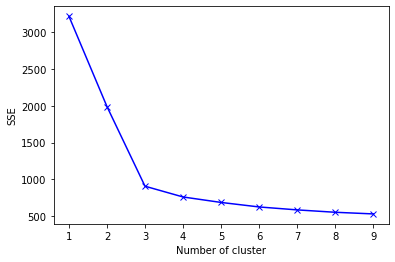

```python
# step 1
sse = {}

# step 2 - iterate for a range of Ks and fit the pca components to the algorithm.
for k in range(1, 10):
    kmeans = KMeans(n_clusters = k, max_iter = 1000, random_state = 1).fit(data_pca)
    sse[k] = kmeans.inertia_     # Use inertia attribute from the clustering object and store the inertia value for that K

# step 3
plt.figure()

plt.plot(list(sse.keys()), list(sse.values()), 'bx-')

plt.xlabel("Number of cluster")

plt.ylabel("SSE")

plt.show()
```

**Observation(s)_______** In the above figure, at the cluster #3 the SSE started stabilizing and alomost moving in parallel to X-axis. So for this dataset the optimum number of clusters is 3.

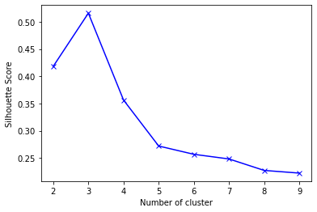

```python
# Just curious to see the Silhouette score

# Empty dictionary to store the Silhouette score for each value of K
# Silhouette score

sc = {}

# Iterate for a range of Ks and fit the scaled data to the algorithm. Store the Silhouette score for that K
for k in range(2, 10):
    kmeans = KMeans(n_clusters = k, random_state = 1).fit(data_pca)

    labels = kmeans.predict(data_pca)

    sc[k] = silhouette_score(data_pca, labels)

# Elbow plot
plt.figure()

plt.plot(list(sc.keys()), list(sc.values()), 'bx-')

plt.xlabel("Number of cluster")

plt.ylabel("Silhouette Score")

plt.show()
```

**Observation(s)**___**** In the above graph it also confirms that for this dataset the optimal value of K is 3, because at K=3, we have the highest Silhouette score.

### **Question 4:**

- **Interpret the above elbow plot and state the reason for choosing K=3 (1 Mark)**
- **Fit the K-means algorithms on the pca components with the number of clusters equal to 3 (2 Mark)**
- **Store the predictions as 'Labels' to the 'data_copy' and 'data' DataFrames (2 Marks)**

**Reason*__*** From the above two graphs, its confirmed that for this dataset the optimal value of K is 3.

```python
kmeans = KMeans(n_clusters = 3, random_state = 1) #___                  # Apply the K-Means algorithm
kmeans.fit(data_pca) #_____________                            # Fit the kmeans function on the pca components

# Adding predicted labels to the original data and the copied data
data_copy['Labels'] = kmeans.predict(data_pca) #____     # Save the predictions on the pca components from K-Means
data['Labels'] = kmeans.predict(data_pca) #_             # Save the predictions on the pca components from K-Means
```

We have generated the labels with K-means. Now, let us look at the various features based on the labels.

### **Question 5: Create the cluster profiles using the below summary statistics and box plots for each label (6 Marks)**

```python
# Number of observations in each cluster
data.Labels.value_counts()
```

```
1    374
0    221
2     49
Name: Labels, dtype: int64
```

```python
# Calculating summary statistics of the original data for each label
mean = data.groupby('Labels').mean()

median = data.groupby('Labels').median()

df_kmeans = pd.concat([mean, median], axis = 0)

df_kmeans.index = ['group_0 Mean', 'group_1 Mean', 'group_2 Mean', 'group_0 Median', 'group_1 Median', 'group_2 Median']

df_kmeans.T
```

|  | group_0 Mean | group_1 Mean | group_2 Mean | group_0 Median | group_1 Median | group_2 Median |
| --- | --- | --- | --- | --- | --- | --- |
| Avg_Credit_Limit | 12239.819005 | 33893.048128 | 140102.040816 | 12000.0 | 31500.0 | 145000.0 |
| Total_Credit_Cards | 2.411765 | 5.508021 | 8.775510 | 2.0 | 6.0 | 9.0 |
| Total_visits_bank | 0.945701 | 3.489305 | 0.591837 | 1.0 | 3.0 | 1.0 |
| Total_visits_online | 3.561086 | 0.975936 | 10.979592 | 4.0 | 1.0 | 11.0 |
| Total_calls_made | 6.891403 | 1.997326 | 1.102041 | 7.0 | 2.0 | 1.0 |

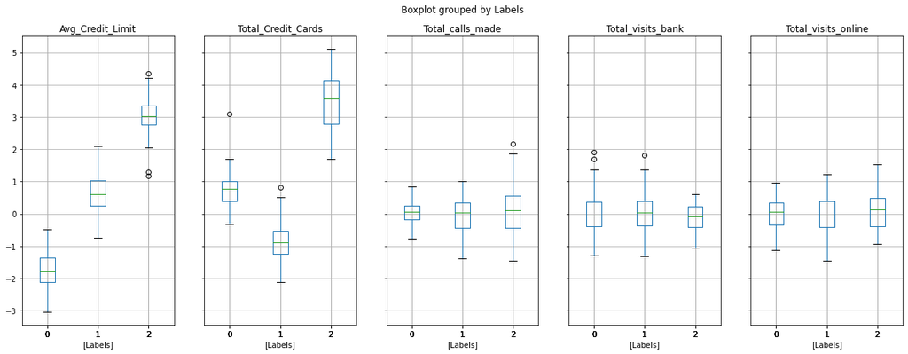

```python
# Visualizing different features w.r.t K-means labels
data_copy.boxplot(by = 'Labels', layout = (1, 5), figsize = (20, 7))

plt.show()
```

**Cluster Profiles:**___****

Group 2: Looking at average credit limit this group seems to be affluent group with highest mean and median credit limits when compared the other two groups. Also possessing more credit cards per person. This group has outliers with respect to acverage credit limit and calls made to bank. Need further analysis here. Group 2's population is very low

Group 1: This group's profile is falling in the middle, with respect to the given dataset attributes. This group members are making more visits to bank when compared to the usage of other service delivery channels, phone calls and online visits respectively. This group has outliers with respect to total credit cards and total bank visits.

Group 0:This group has the lowest number of credit cards per member. This group has outliers similar to "Group 1". May be some datapoints might be closely neighboring with "Group 1" cluster.

## **Gaussian Mixture Model**

Let's now create clusters using the Gaussian Mixture Model.

### **Question 6:**

- **Apply the Gaussian Mixture Model algorithm on the pca components with n_components=3 and random_state=1 (2 Marks)**
- **Create the cluster profiles using the below summary statistics and box plots for each label (2 Marks)**
- **Compare the clusters from both algorithms - K-means and Gaussian Mixture Model (1 Mark)**

```python
gmm = GaussianMixture(n_components = 3, random_state = 1) # Apply the Gaussian Mixture algorithm on the pca components with n_components=3 and random_state=1

gmm.fit(data_pca)    # Fit the model on the pca components

data_copy['GmmLabels'] = gmm.predict(data_pca)

data['GmmLabels'] = gmm.predict(data_pca)
```

```python
# Number of observations/data points in each cluster
data.GmmLabels.value_counts()
```

```
1    374
0    221
2     49
Name: GmmLabels, dtype: int64
```

```python
# Calculating the summary statistics of the original data for each label
original_features = ["Avg_Credit_Limit", "Total_Credit_Cards", "Total_visits_bank", "Total_visits_online", "Total_calls_made"]

mean = data.groupby('GmmLabels').mean()

median = data.groupby('GmmLabels').median()

df_gmm = pd.concat([mean, median], axis = 0)

df_gmm.index = ['group_0 Mean', 'group_1 Mean', 'group_2 Mean', 'group_0 Median', 'group_1 Median', 'group_2 Median']

df_gmm[original_features].T
```

|  | group_0 Mean | group_1 Mean | group_2 Mean | group_0 Median | group_1 Median | group_2 Median |
| --- | --- | --- | --- | --- | --- | --- |
| Avg_Credit_Limit | 12239.819005 | 33893.048128 | 140102.040816 | 12000.0 | 31500.0 | 145000.0 |
| Total_Credit_Cards | 2.411765 | 5.508021 | 8.775510 | 2.0 | 6.0 | 9.0 |
| Total_visits_bank | 0.945701 | 3.489305 | 0.591837 | 1.0 | 3.0 | 1.0 |
| Total_visits_online | 3.561086 | 0.975936 | 10.979592 | 4.0 | 1.0 | 11.0 |
| Total_calls_made | 6.891403 | 1.997326 | 1.102041 | 7.0 | 2.0 | 1.0 |

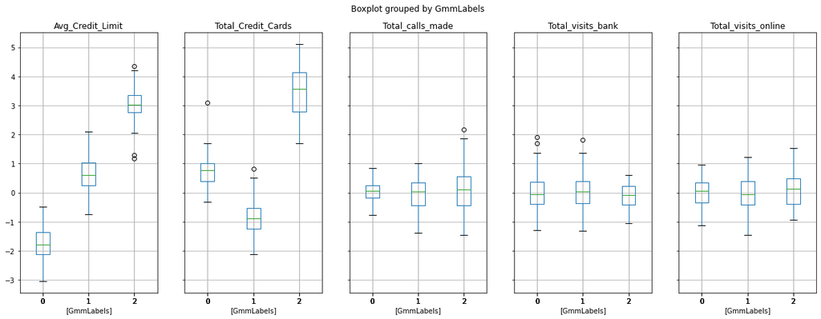

```python
# Plotting boxplots with the new GMM based labels

features_with_lables = ["Avg_Credit_Limit", "Total_Credit_Cards", "Total_visits_bank", "Total_visits_online", "Total_calls_made", "GmmLabels"]

data_copy[features_with_lables].boxplot(by = 'GmmLabels', layout = (1, 5),figsize = (20, 7))

plt.show()
```

```python
comparison = pd.concat([df_kmeans, df_gmm], axis = 1)[original_features] #Comparison K-Means & GMM

comparison
```

|  | Avg_Credit_Limit | Avg_Credit_Limit | Total_Credit_Cards | Total_Credit_Cards | Total_visits_bank | Total_visits_bank | Total_visits_online | Total_visits_online | Total_calls_made | Total_calls_made |
| --- | --- | --- | --- | --- | --- | --- | --- | --- | --- | --- |
| group_0 Mean | 12239.819005 | 12239.819005 | 2.411765 | 2.411765 | 0.945701 | 0.945701 | 3.561086 | 3.561086 | 6.891403 | 6.891403 |
| group_1 Mean | 33893.048128 | 33893.048128 | 5.508021 | 5.508021 | 3.489305 | 3.489305 | 0.975936 | 0.975936 | 1.997326 | 1.997326 |
| group_2 Mean | 140102.040816 | 140102.040816 | 8.775510 | 8.775510 | 0.591837 | 0.591837 | 10.979592 | 10.979592 | 1.102041 | 1.102041 |
| group_0 Median | 12000.000000 | 12000.000000 | 2.000000 | 2.000000 | 1.000000 | 1.000000 | 4.000000 | 4.000000 | 7.000000 | 7.000000 |
| group_1 Median | 31500.000000 | 31500.000000 | 6.000000 | 6.000000 | 3.000000 | 3.000000 | 1.000000 | 1.000000 | 2.000000 | 2.000000 |
| group_2 Median | 145000.000000 | 145000.000000 | 9.000000 | 9.000000 | 1.000000 | 1.000000 | 11.000000 | 11.000000 | 1.000000 | 1.000000 |

**Cluster Profiles:*__*** Surprised!!! I didn't expect the Gaussian Mixture Model to spit the same summary statistics as K-Means. So my cluster profile summary is same as above (from Q5).

**Comparing Clusters:*__*** Based on theory reading - Cluster boundaries are more or less circular in K_Means, where as in GMM they are elliptical in shape. In addition GMM gives probabilities for a data point with respect to the cluster(s) it belongs to.

## **K-Medoids**

### **Question 7:**

- **Apply the K-Medoids clustering algorithm on the pca components with n_clusters=3 and random_state=1 (2 Marks)**
- **Create cluster profiles using the below summary statistics and box plots for each label (2 Marks)**
- **Compare the clusters from both algorithms - K-Means and K-Medoids (2 Marks)**

```python
kmedo = KMedoids(n_clusters = 3, random_state = 1) #_ Apply the K-Medoids algorithm on the pca components with n_components=3 and random_state=1

kmedo.fit(data_pca) #_ Fit the model on the pca components

data_copy['kmedoLabels'] = kmedo.predict(data_pca)

data['kmedoLabels'] = kmedo.predict(data_pca)
```

```python
# Number of observations in each cluster
data.kmedoLabels.value_counts()
```

```
2    289
0    222
1    133
Name: kmedoLabels, dtype: int64
```

```python
# Calculating summary statistics of the original data for each label
mean = data.groupby('kmedoLabels').mean()

median = data.groupby('kmedoLabels').median()

df_kmedoids = pd.concat([mean, median], axis = 0)

df_kmedoids.index = ['group_0 Mean', 'group_1 Mean', 'group_2 Mean', 'group_0 Median', 'group_1 Median', 'group_2 Median']

df_kmedoids[original_features].T
```

|  | group_0 Mean | group_1 Mean | group_2 Mean | group_0 Median | group_1 Median | group_2 Median |
| --- | --- | --- | --- | --- | --- | --- |
| Avg_Credit_Limit | 12216.216216 | 85052.631579 | 28449.826990 | 12000.0 | 68000.0 | 20000.0 |
| Total_Credit_Cards | 2.423423 | 7.030075 | 5.363322 | 2.0 | 7.0 | 5.0 |
| Total_visits_bank | 0.950450 | 1.691729 | 3.830450 | 1.0 | 2.0 | 4.0 |
| Total_visits_online | 3.554054 | 4.639098 | 0.982699 | 4.0 | 2.0 | 1.0 |
| Total_calls_made | 6.878378 | 1.969925 | 1.851211 | 7.0 | 2.0 | 2.0 |

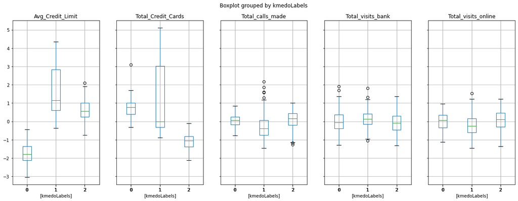

```python
# Plotting boxplots with the new K-Medoids based labels

features_with_lables = ["Avg_Credit_Limit", "Total_Credit_Cards", "Total_visits_bank", "Total_visits_online", "Total_calls_made", "kmedoLabels"]

data_copy[features_with_lables].boxplot(by = 'kmedoLabels', layout = (1, 5), figsize = (20, 7))

plt.show()
```

**Cluster Profiles:*__*** First and foremost the cluster distribution seems more or less even with K-Medoids when compared the K-Means label value counts.

Group 0: This group seems very prudent with debt, with an average of only two cards and out of the three service delivery options available, it seems their preferred choice is to make calls to bank, then online visit before stepping into the bank.

Group 1: This group has the highest average credit limit, as well as having highest credit cardsper person when compared to the two other groups. This group seems tech savy whith more online visits than making calls or visitng bank. There are some outliers with respect to calls made or bank visits. If those outliers are properly recognized or designated to clusters then these calls made and banks visits number may further go down.

Let's compare the clusters from K-Means and K-Medoids

```python
comparison = pd.concat([df_kmedoids, df_kmeans], axis = 1)[original_features]

comparison
```

|  | Avg_Credit_Limit | Avg_Credit_Limit | Total_Credit_Cards | Total_Credit_Cards | Total_visits_bank | Total_visits_bank | Total_visits_online | Total_visits_online | Total_calls_made | Total_calls_made |
| --- | --- | --- | --- | --- | --- | --- | --- | --- | --- | --- |
| group_0 Mean | 12216.216216 | 12239.819005 | 2.423423 | 2.411765 | 0.950450 | 0.945701 | 3.554054 | 3.561086 | 6.878378 | 6.891403 |
| group_1 Mean | 85052.631579 | 33893.048128 | 7.030075 | 5.508021 | 1.691729 | 3.489305 | 4.639098 | 0.975936 | 1.969925 | 1.997326 |
| group_2 Mean | 28449.826990 | 140102.040816 | 5.363322 | 8.775510 | 3.830450 | 0.591837 | 0.982699 | 10.979592 | 1.851211 | 1.102041 |
| group_0 Median | 12000.000000 | 12000.000000 | 2.000000 | 2.000000 | 1.000000 | 1.000000 | 4.000000 | 4.000000 | 7.000000 | 7.000000 |
| group_1 Median | 68000.000000 | 31500.000000 | 7.000000 | 6.000000 | 2.000000 | 3.000000 | 2.000000 | 1.000000 | 2.000000 | 2.000000 |
| group_2 Median | 20000.000000 | 145000.000000 | 5.000000 | 9.000000 | 4.000000 | 1.000000 | 1.000000 | 11.000000 | 2.000000 | 1.000000 |

**Comparing Clusters:**___****

Group 0 stayed more or less stable between K-Means & K-Medoids clustering algorithms.Their choice of service delivery is making calls to the bank then visit online.Bank has the opporrtunity to market (responsible marketing, not predatory) more products, in turn more credits cards to this group.

Group 1: With K-Medoids, Group 1 has highest average credit limit, more total credit cards and seems this group is more tech savy with more online visits compared to other two options of the service delivery. So bank should enhance/upgade their online service delivery for this group's customers. Targeted personalized online marketing may have more bank for buck with this group.